# 05 Audiemus-Plaattform

Peter Baumgartner

2017-03-23

# Einsatz von Audiemus

```r
library(forcats)
table(umfrage$a.eingesetzt, umfrage$schultyp, useNA = "ifany")
```

```
       AHS NMS PTS
  ja     1   5   6
  nein   4  12   5
  <NA>   0   1   2
```

```r
table(umfrage$t.pc.nein, umfrage$schultyp, useNA = "ifany")
```

```
                  AHS NMS PTS
  sehr gut          1   1   0
  ausreichend       1   4   6
  ausbaufähig       2   4   2
  schlecht          0   0   1
  nicht vorhanden   1   9   3
  <NA>              0   0   1
```

```r
table(umfrage$t.pc.ja, umfrage$schultyp, useNA = "always")
```

```
              AHS NMS PTS <NA>
  sehr gut      2   9   5    0
  ausreichend   1   6   7    0
  ausbaufähig   2   3   0    0
  <NA>          0   0   1    0
```

```r
fct_count(umfrage$a.eingesetzt)
```

| f | n |
| --- | --- |
| ja | 12 |
| nein | 21 |
| NA | 3 |

```r
count(umfrage, a.eingesetzt)
```

| a.eingesetzt | n |
| --- | --- |
| ja | 12 |
| nein | 21 |
| NA | 3 |

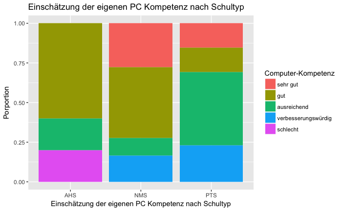

```r
bp <- ggplot(data = umfrage) +
        geom_bar(
                mapping = aes(x = schultyp, fill = k.computer),
                position = "fill"
                )
bp <- bp + ggtitle("Einschätzung der eigenen PC Kompetenz nach Schultyp")
bp <- bp + xlab("Einschätzung der eigenen PC Kompetenz nach Schultyp")
bp <- bp + ylab("Porportion")
bp <- bp + guides(fill = guide_legend(title = "Computer-Kompetenz"))
bp
```

Zuerst einmal: Es ist wichtig, dass sich hier ein differenziertes Bild zeigt, weil ansonsten der Verdacht nahe liegen würde, dass die Befragten keine repräsentative Auswahl darstellen, sondern - wie ja vielleicht im Zusammenhang einer Internet-Plattform zu vermuten wäre - eher aus der computer-affinen Lehrer/innen-Gruppe stammen. Allerdings ist es immer noch ein recht positives Bild das sich hier zeigt. Weit üer drei Viertel der Befragten schätzt die eigenen Kenntnisse zumindest als ausreichend ein.

# Mediendidaktik-Kompetenz

```r
table(umfrage$schultyp, umfrage$k.didaktik)
```

```
      sehr gut gut ausreichend verbesserungswürdig
  AHS        0   0           4                   1
  NMS        3  10           4                   1
  PTS        1   3           2                   6
```

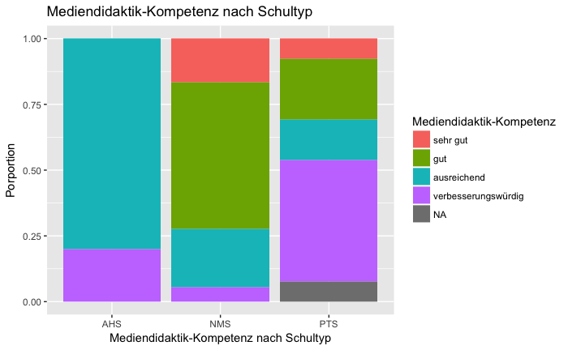

```r
bp <- ggplot(data = umfrage) +
        geom_bar(
                mapping = aes(x = schultyp, fill = k.didaktik),
                position = "fill"
                )
bp <- bp + ggtitle("Mediendidaktik-Kompetenz nach Schultyp")
bp <- bp + xlab("Mediendidaktik-Kompetenz nach Schultyp")
bp <- bp + ylab("Porportion")
bp <- bp + guides(fill = guide_legend(title = "Mediendidaktik-Kompetenz"))
bp
```

Im Verhältnis zur PC-Kompetenz wird die eigene Medienkomptenz schlechter eingeschätzt. Das trifft sich auch mit den im Nationalen Bildungsbericht 2015 erwähnten Untersuchungen. Darin zeigte sich nämlich, dass ein sehr hoher Prozentsatz an Lehrer/innen interaktive Medien als administrative Werkzeuge und zur Unterrichtsvorbeeitung nutzen, dass aber der mediendidaktische Einsatz im Unterricht bei weitem nicht dieses Niveau erreicht.

Eine Erklärung für diesen unterschiedlichen Verbreitungsgrad dürfte gerade in den unterschiedlich gelagerten Kompetenzen liegen. Zur obigen Grafik ist ja außerdem noch anzumerken, dass Erfahrung zeigt, dass selbskritische Antworten nicht leichtfertig gegeben werden. Es liegt daher die Vermutung nahe, dass die in der oben dargestellten Grafik durchwachsene Situation in der Mediendidaktik bei objektivierbaren Kompetenz-Messungstests noch etwas schlechter als die Selbsteinschätzung ausfallen würde.

Dieser Vermutung sollte noch detaillierter nachgehen. Aber wie???

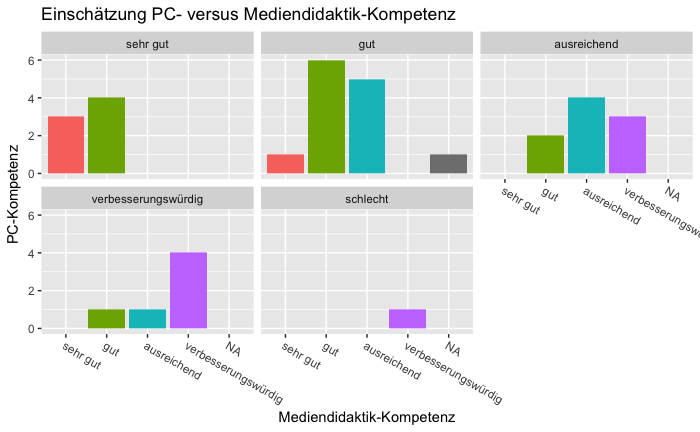

```r
# umfrage$k.computer <- recode(umfrage$k.computer, "sehr gut" = "PC sehr gut", "gut" = "PC gut", "ausreichend" = "PC ausreichend", "verbesserungswürdig" = "PC verbesserungswürdig", "schlecht" = "PC schlecht")
#
# umfrage$k.didaktik <- recode(umfrage$k.didaktik, "sehr gut" = "Didaktik sehr gut", "gut" = "Didaktik gut", "ausreichend" = "Didaktik ausreichend", "verbesserungswürdig" = "Didaktik verbesserungswürdig", "schlecht" = "Didaitk schlecht")
bp <- ggplot(umfrage, aes(k.didaktik, fill = k.didaktik)) +
        geom_bar() +
        theme(axis.text.x = element_text(angle = -30, vjust = 1, hjust = 0)) +
        facet_wrap(~k.computer)
bp <- bp + ggtitle("Einschätzung PC- versus Mediendidaktik-Kompetenz")
bp <- bp + xlab("Mediendidaktik-Kompetenz")
bp <- bp + ylab("PC-Kompetenz")
bp <- bp + guides(fill = FALSE)
bp
```

Die Grafik zeigt eine leicht bessere Einschätzung zur Computer-Kompetenz versus Medien-Kompetenz.

# Motivation für Medieneinsatz im Unterricht

```r
table(umfrage$schultyp, umfrage$k.motivation)
```

```
      sehr gut gut ausreichend verbesserungswürdig
  AHS        1   0           2                   2
  NMS        5   8           2                   3
  PTS        4   1           3                   5
```

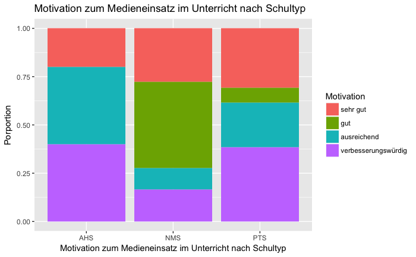

```r
bp <- ggplot(data = umfrage) +
        geom_bar(
                mapping = aes(x = schultyp, fill = k.motivation),
                position = "fill"
                )
bp <- bp + ggtitle("Motivation zum Medieneinsatz im Unterricht nach Schultyp")
bp <- bp + xlab("Motivation zum Medieneinsatz im Unterricht nach Schultyp")
bp <- bp + ylab("Porportion")
bp <- bp + guides(fill = guide_legend(title = "Motivation"))
bp
```

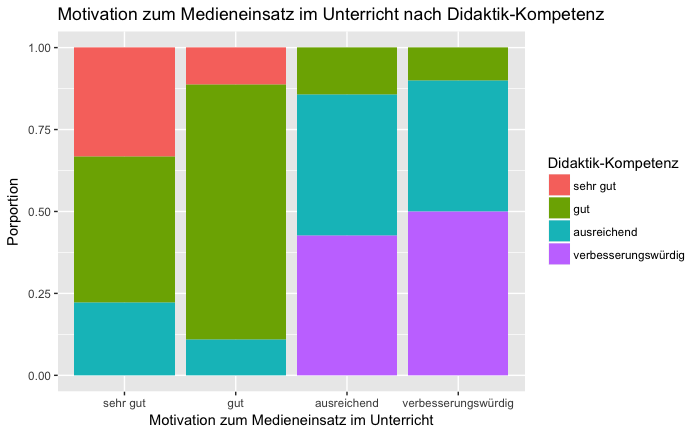

```r
bp <- ggplot(data = subset(umfrage, !is.na(k.didaktik))) +
        geom_bar(
                mapping = aes(x = k.motivation, fill = k.didaktik),
                position = "fill"
                )
bp <- bp + ggtitle("Motivation zum Medieneinsatz im Unterricht nach Didaktik-Kompetenz")
bp <- bp + xlab("Motivation zum Medieneinsatz im Unterricht")
bp <- bp + ylab("Porportion")
bp <- bp + guides(fill = guide_legend(title = "Didaktik-Kompetenz"))
bp
```

Das ist insofern ein interessantes Ergebnis, als sich darin deutlich wiederspiegelt, dass die Motivation Medien im Unterricht einzusetzen, stark mit der Einschätzung der eigenen Mediendidaktik-Kompetenz zusammenhängt.

# Medienkompetenz von Schüler/innen

```r
table(umfrage$schultyp, umfrage$k.schueler)
```

```
      sehr gut gut ausreichend verbesserungswürdig
  AHS        2   1           2                   0
  NMS        1   7           4                   6
  PTS        1   2           5                   5
```

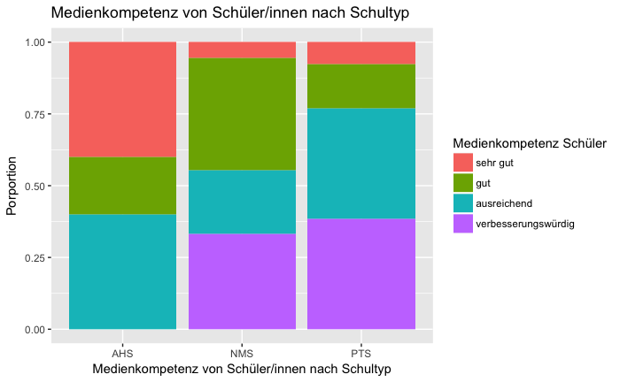

```r
bp <- ggplot(data = umfrage) +
        geom_bar(
                mapping = aes(x = schultyp, fill = k.schueler),
                position = "fill"
                )
bp <- bp + ggtitle("Medienkompetenz von Schüler/innen nach Schultyp")
bp <- bp + xlab("Medienkompetenz von Schüler/innen nach Schultyp")
bp <- bp + ylab("Porportion")
bp <- bp + guides(fill = guide_legend(title = "Medienkompetenz Schüler"))
bp
```

# Fördert die Schule Medienkompetenz?

```r
table(umfrage$schultyp, umfrage$k.schule)
```

```
      sehr gut gut ausreichend verbesserungswürdig
  AHS        2   2           1                   0
  NMS        2   8           5                   3
  PTS        1   3           4                   4
```

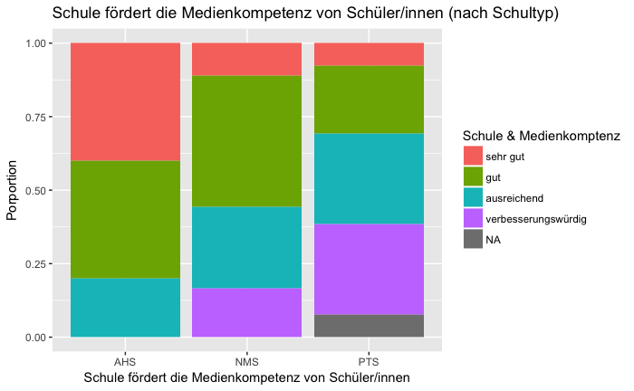

```r
bp <- ggplot(data = umfrage) +
        geom_bar(
                mapping = aes(x = schultyp, fill = k.schule),
                position = "fill"
                )
bp <- bp + ggtitle("Schule fördert die Medienkompetenz von Schüler/innen (nach Schultyp)")
bp <- bp + xlab("Schule fördert die Medienkompetenz von Schüler/innen")
bp <- bp + ylab("Porportion")
bp <- bp + guides(fill = guide_legend(title = "Schule & Medienkomptenz"))
bp
```

# IT Systembetreuung

```r
table(umfrage$schultyp, umfrage$k.it.betreuung)
```

```
      sehr gut gut ausreichend verbesserungswürdig
  AHS        3   0           1                   1
  NMS        7   5           5                   1
  PTS        3   4           4                   1
```

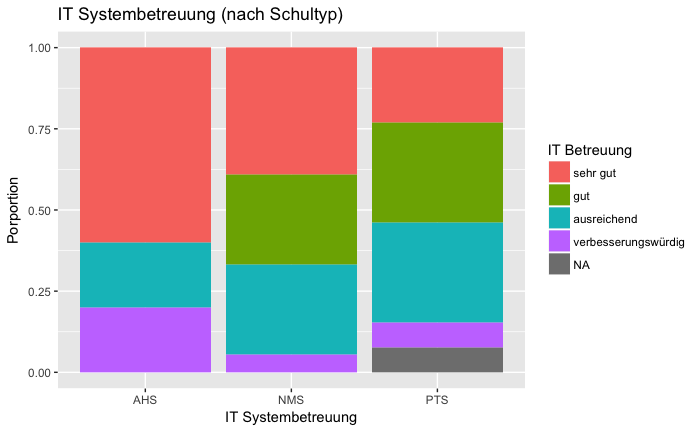

```r
bp <- ggplot(data = umfrage) +
        geom_bar(
                mapping = aes(x = schultyp, fill = k.it.betreuung),
                position = "fill"
                )
bp <- bp + ggtitle("IT Systembetreuung (nach Schultyp)")
bp <- bp + xlab("IT Systembetreuung")
bp <- bp + ylab("Porportion")
bp <- bp + guides(fill = guide_legend(title = "IT Betreuung"))
bp
```